# Physical health and subjective vision & hearing

[back to Home page |](https://github.com/huiwen-goy/C2-multidomain) [back to Analyses page |](https://huiwen-goy.github.io/C2-multidomain/C2-11Analyses.html) [Data quality |](https://huiwen-goy.github.io/C2-multidomain/C2-1Quality.html)

[Demographics |](https://huiwen-goy.github.io/C2-multidomain/C2-2Demographic.html) [Physical health |](https://huiwen-goy.github.io/C2-multidomain/C2-3Physical.html) [Hearing |](https://huiwen-goy.github.io/C2-multidomain/C2-4Hearing.html) [Cognition |](https://huiwen-goy.github.io/C2-multidomain/C2-5Cognition.html) [Mobility and balance |](https://huiwen-goy.github.io/C2-multidomain/C2-6Mobility.html) [Quality of life |](https://huiwen-goy.github.io/C2-multidomain/C2-7QoL.html) [Mental health |](https://huiwen-goy.github.io/C2-multidomain/C2-8Mental.html) [Social |](https://huiwen-goy.github.io/C2-multidomain/C2-9Social.html) [Views |](https://huiwen-goy.github.io/C2-multidomain/C2-10Views.html)

# Physical health self-rating

Responses are discrete options, ranging from 1 (poor) to 5 (excellent).

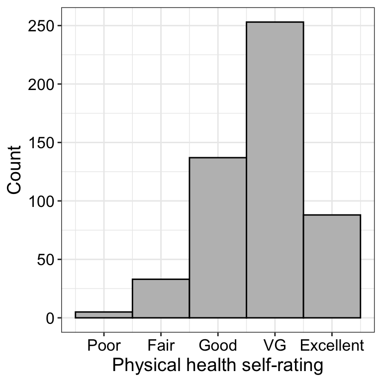

# Co-morbidities

back to top

Responses are 3 discrete options, Yes / No / Don’t know.

```
##                     % Yes
## cataracts      29.2220114
## eye            11.3851992
## allergies      37.0018975
## asthma          9.4876660
## lung            3.4155598
## hyperglycemia  11.7647059
## hypothyroid    11.5749526
## hyperthyroid    2.0872865
## cancer          9.1081594
## heart           5.3130930
## vascular        4.5540797
## highbp         28.0834915
## stroke          3.4155598
## kidney          2.8462998
## urinary.incont 11.3851992
## ulcers          3.2258065
## bowel.disorder  6.6413662
## bowel.incont    3.9848197
## osteoarthritis 26.1859583
## rheumatoid      3.7950664
## arthritis      11.9544592
## osteoporosis   10.0569260
## back           20.4933586
## memory         10.6261860
## dementia        0.1897533
## parkinson       0.7590133
## ms              0.3795066
## epilepsy        0.5692600
## migraine        9.2979127
## anxiety         5.8823529
## depression      9.2979127
```

# Multimorbidity score

back to top

The sum of “Yes” responses per participant for 31 diseases.

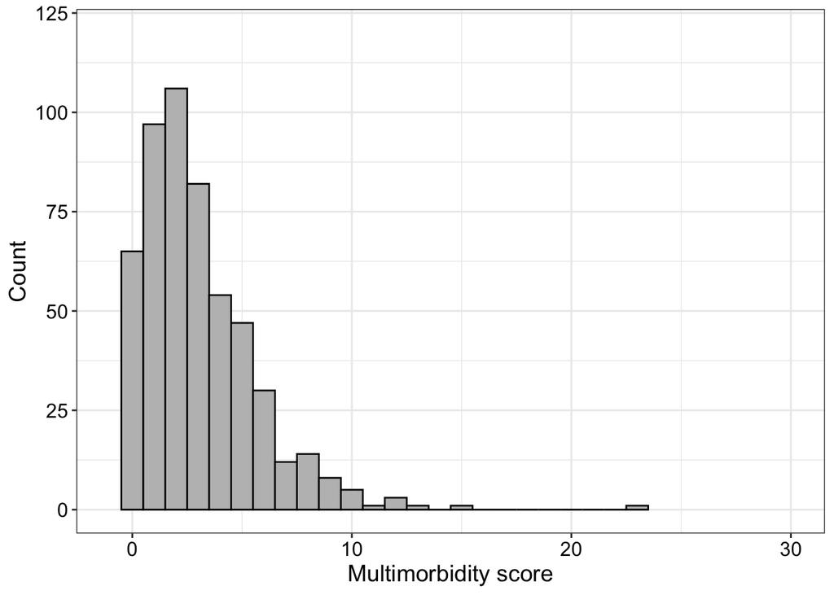

WHO hearing loss categories: None (< 20); Mild (20-35), Moderate (35-50), Moderately Severe (50-65 dB HL). (79 participants are missing audiometric information.)

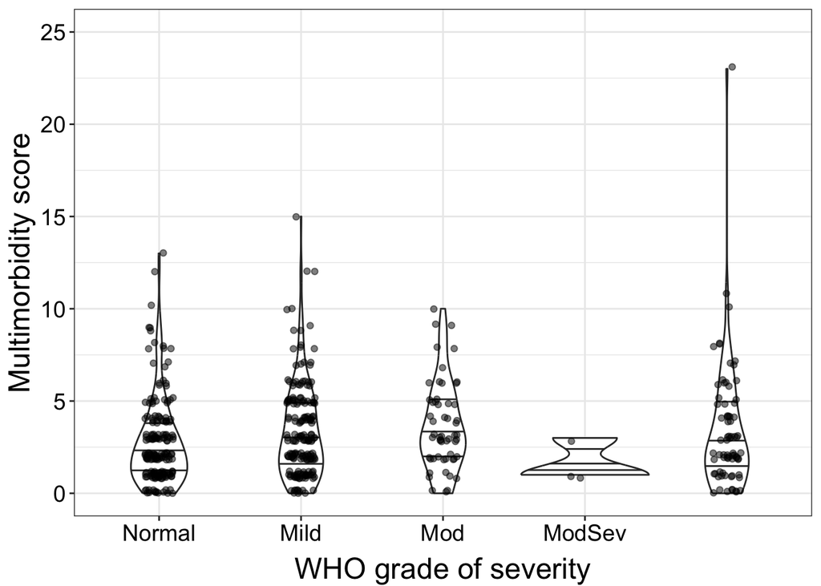

% participants in each WHO category with 0, 1, 2 or 3+ co-morbidities. Columns sum to 100%.

```
##
##      Normal Mild  Mod ModSev
##   0    13.4 10.4 10.3    0.0
##   1    23.2 17.6  8.6   66.7
##   2    21.6 18.7 17.2    0.0
##   3+   41.8 53.4 63.8   33.3
```

Temporarily adding 3 cases of ModSev to Mod group (means, t-test results):

```
##
## Normal   Mild    Mod ModSev   <NA>
##    194    193     58      3     79
```

```
##
## Normal   Mild    Mod   <NA>
##    194    193     61     79
```

```
## Normal   Mild    Mod
##   2.63   3.25   3.43
```

```
##
##  Pairwise comparisons using t tests with pooled SD
##
## data:  data$multimorbidity_score and data$WHO_hearing_cat_temp
##
##      Normal Mild
## Mild 0.040  -
## Mod  0.054  0.622
##
## P value adjustment method: holm
```

# Potentially modifiable risk factors for hearing loss

back to top

- high blood pressure or hypertension
- diabetes, borderline diabetes or high blood sugar
- peripheral vascular disease or poor circulation in your limbs
- heart disease, including congestive heart failure, angina, heart aiack or myocardial infarction
- lung disorder, including emphysema, chronic bronchitis, chronic obstructive pulmonary disease, etc
- osteoarthritis
- any other type of arthritis
- rheumatoid arthritis

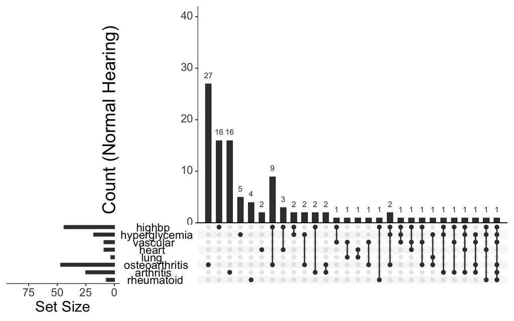

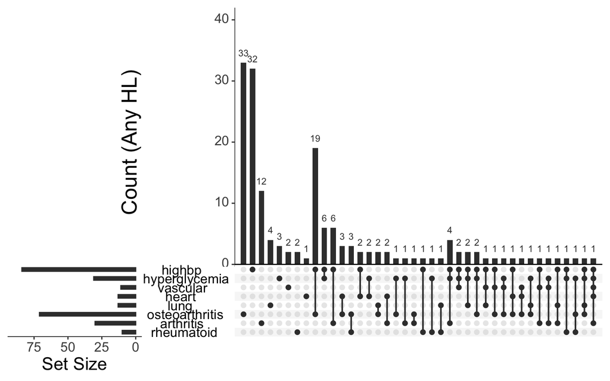

Of the eight risk factors above, hypertension is the only one that predicts having any degree of hearing loss.

```
##
## Call:
## glm(formula = as.formula(tempformula), family = binomial("logit"),
##     data = compco)
##
## Coefficients:
##                Estimate Std. Error z value Pr(>|z|)
## (Intercept)     0.05290    0.13583   0.389   0.6970
## rheumatoid      0.02697    0.51300   0.053   0.9581
## arthritis      -0.06718    0.30030  -0.224   0.8230
## osteoarthritis  0.16788    0.22387   0.750   0.4533
## lung            1.23181    0.65608   1.878   0.0604 .
## heart           0.02677    0.45484   0.059   0.9531
## vascular       -0.37154    0.48929  -0.759   0.4476
## hyperglycemia   0.12784    0.33859   0.378   0.7057
## highbp          0.52449    0.22584   2.322   0.0202 *
## ---
## Signif. codes:  0 '***' 0.001 '**' 0.01 '*' 0.05 '.' 0.1 ' ' 1
##
## (Dispersion parameter for binomial family taken to be 1)
##
##     Null deviance: 613.00  on 447  degrees of freedom
## Residual deviance: 601.38  on 439  degrees of freedom
## AIC: 619.38
##
## Number of Fisher Scoring iterations: 4
```

```
##                OddsRatio     2.5 %    97.5 %
## (Intercept)    1.0543196 0.8077473  1.376661
## rheumatoid     1.0273362 0.3785445  2.928905
## arthritis      0.9350283 0.5192591  1.693653
## osteoarthritis 1.1827929 0.7642601  1.840876
## lung           3.4274430 1.0654843 15.287713
## heart          1.0271266 0.4246064  2.585315
## vascular       0.6896686 0.2631961  1.836448
## hyperglycemia  1.1363756 0.5893019  2.239480
## highbp         1.6896028 1.0900052  2.646353
```

# Subjective vision

back to top

Responses are 3 discrete options, Yes / No / Don’t know.

```
##   Subjective_vision_loss    %
## 1                    Yes 55.0
## 2                     No 40.8
## 3             Don't know  3.6
## 4                   <NA>  0.6
```

```
##   Subjective_vision_rating    %
## 1                     Poor  0.2
## 2                     Fair  2.7
## 3                     Good 18.0
## 4                Very good 50.1
## 5                Excellent 28.1
## 6                     <NA>  0.9
```

# Subjective hearing

back to top

Responses are 3 discrete options, Yes / No / Don’t know.

Observation: Respondents seem to be confused by the question “Is your hearing, using a hearing aid if you use one…”, resulting in 32% N/A’s, even though they don’t seem to be confused by the vision version of the same question just before (“Is your eyesight, using glasses or corrective lens if you use them…”). Nor are they confused by the next question, “Is your hearing, without a hearing aid…”.

```
##   Subjective_hearing_loss    %
## 1                     Yes 62.0
## 2                      No 30.2
## 3              Don't know  0.0
## 4                    <NA>  7.8
```

```
##   Age_subj_HL_began    %
## 1               0-5  0.6
## 2              6-10  1.5
## 3             11-20  2.1
## 4             21-40 10.1
## 5             41-60 37.6
## 6           Over 60 44.3
## 7              <NA>  3.7
```

```
##   Subj_hearing_rating_Aids    %
## 1                     Poor  1.5
## 2                     Fair  7.6
## 3                     Good 21.3
## 4                Very good 22.4
## 5                Excellent 15.2
## 6                     <NA> 32.1
```

```
##   Subj_hearing_rating_NoAids    %
## 1                       Poor  1.9
## 2                       Fair 27.3
## 3                       Good 36.4
## 4                  Very good 21.8
## 5                  Excellent 10.1
## 6                       <NA>  2.5
```

```
##
##             noHA   HA
##   Poor       3.1  0.0
##   Fair      14.9  1.9
##   Good      33.3 26.2
##   Very good 27.1 47.6
##   Excellent 21.6 24.3
```

# Dual sensory impairment (subjective)

Impairment = subjective rating of either “Fair” or “Poor”, using whatever aids they normally would. Note that we have no vision measures except subjective self-report and reported vision diagnoses. There are only 3 respondents classified as having dual sensory impairment.

```
##                       Subj_hearing_impairment
## Subj_vision_impairment Normal Impaired <NA>
##               Normal      303       45  159
##               Impaired      7        3    5
##               <NA>          0        0    5
```

# Other variables available

back to top

- Age when vision loss began
- Type of aids used for vision (very few) and hearing (almost all hearing aids)
- Date of last checkup for vision and hearing